# Seca em Portugal

Vasco Pereira

2022.03.26

## Bibliotecas

```r
library(dplyr)
library(readr)
library(ggplot2)
library(lubridate)
```

## Dados

A obtenção dos dados foi efectuada através do GitHub da [DSSG Portugal](https://github.com/dssgPT)

```r
## Code commented, uncomment only for the first run
# water_data_url <- "https://github.com/dssgPT/Plotting-Good-DSSG/blob/main/desafios/001_Seca_Em_Portugal_SNIRH/snirh_clean.csv?raw=true"
# download.file(water_data_url, "droughts/files/water_data.csv")
```

### Exploração dos dados

```r
water_data <- read_csv("../files/water_data.csv")
str(water_data)
```

```
## spec_tbl_df [37,596 × 6] (S3: spec_tbl_df/tbl_df/tbl/data.frame)
##  $ ...1                  : num [1:37596] 0 1 2 3 4 5 6 7 8 9 ...
##  $ nome_infraestrutura   : chr [1:37596] "ARADE" "ARADE" "ARADE" "ARADE" ...
##  $ resumo_infraestrutura : chr [1:37596] "108.1" "114.5" "128.8" "130.0" ...
##  $ data                  : Date[1:37596], format: "2020-10-01" "2020-11-01" ...
##  $ tipo_de_infraestrutura: chr [1:37596] "bacia" "bacia" "bacia" "bacia" ...
##  $ medida                : chr [1:37596] "metro_cubico" "metro_cubico" "metro_cubico" "metro_cubico" ...
##  - attr(*, "spec")=
##   .. cols(
##   ..   ...1 = col_double(),
##   ..   nome_infraestrutura = col_character(),
##   ..   resumo_infraestrutura = col_character(),
##   ..   data = col_date(format = ""),
##   ..   tipo_de_infraestrutura = col_character(),
##   ..   medida = col_character()
##   .. )
##  - attr(*, "problems")=<externalptr>
```

Pelo que se consegue observar pode-se eliminar a primeira coluna pois não tem informação útil; a `data` está correctamente formatada e pelo dicionário de dados fornecido pela dssgPT trata-se de uma data arredondada ao primeiro dia de cada mês, pelo que se pode considerar apenas o mês e ano; também pelo dicionário de dados observa-se dois tipos de medida: metros cúbicos ou percentagem quanto à coluna `medida`, no entanto o `resumo_infraestrutura` é suposto ser numérico pelo que terá de ser convertido.

A coluna `nome_infraestrutura` apresenta-se desta forma:

RIBEIRAS DO OESTE, SADO, TEJO, Arade, Funcho, Odelouca

Para bem da uniformidade todos os nomes serão convertidos para maíusculas. Para terminar a coluna `tipo_infraestrutura` explicita se se trata de uma bacia ou albufeira.

### Filtragem e conversão numérica

Decidiu-se filtrar os dados por **percentagem**; as restantes alterações acima mencionadas foram aplicadas para a nova tabela `water_percent`. Ao transformar-se a quantidade percentual de água nalgumas linhas geraram-se NA, pelo que estas linhas foram eliminadas da tabela.

Primeiras 10 linhas da tabela `water_percent`:

```r
water_percent <- water_data[,-1] %>%
  filter(medida == "percentagem") %>%
  mutate(nome_infraestrutura = toupper(nome_infraestrutura),
         resumo_infraestrutura = as.numeric(resumo_infraestrutura)) %>%
  na.omit()

knitr::kable(head(water_percent, 10))
```

| nome_infraestrutura | resumo_infraestrutura | data | tipo_de_infraestrutura | medida |
| --- | --- | --- | --- | --- |
| ARADE | 46.4 | 2020-10-01 | bacia | percentagem |
| ARADE | 49.1 | 2020-11-01 | bacia | percentagem |
| ARADE | 55.2 | 2020-12-01 | bacia | percentagem |
| ARADE | 55.8 | 2021-01-01 | bacia | percentagem |
| ARADE | 72.8 | 2021-02-01 | bacia | percentagem |
| ARADE | 76.4 | 2021-03-01 | bacia | percentagem |
| ARADE | 75.3 | 2021-04-01 | bacia | percentagem |
| ARADE | 72.8 | 2021-05-01 | bacia | percentagem |
| ARADE | 69.4 | 2021-06-01 | bacia | percentagem |
| ARADE | 65.3 | 2021-07-01 | bacia | percentagem |

## Determinação da variação

Assumindo que periodos de seca extrema acompanhados de excessiva precipitação são mais prejudiciais para as rotinas agrículas e para a disponíbilidade de água para pessoas e animais de uma localização geográfica, neste caso Portugal, determinaram-se quais as doze albufeiras/bacias que apresentam maior variabilidade de disponibilidade de água ao longo do anos em que os dados foram obtidos:

```r
varWater <- water_percent %>%
  mutate(ano = year(data)) %>%
  group_by(ano, nome_infraestrutura) %>%
  summarise(media = mean(resumo_infraestrutura)) %>%
  group_by(nome_infraestrutura) %>%
  summarise(variacao = var(media)) %>%
  arrange(desc(variacao))

mySearch <- head(varWater$nome_infraestrutura,12)
print(mySearch)
```

```
##  [1] "CAMPILHAS"           "MONTE DA ROCHA"      "DIVOR"
##  [4] "MONTE GATO"          "VIGIA"               "RIBEIRAS DO ALGARVE"
##  [7] "ABRILONGO"           "PEGO DO ALTAR"       "BRAVURA"
## [10] "MINUTOS"             "VALE DO GAIO"        "FAGILDE"
```

## Média Percentual por Ano

A tabela `water_percent` foi filtrada para conter apenas dados das albufeiras/bacias anteriormente descritas. Adicionalmente realizou-se uma média anual. Nomeou-se a nova tabela de `water_subset`.

Primeiras 10 linhas da tabela `water_subset`:

```r
water_subset <- water_percent %>% filter(nome_infraestrutura %in% mySearch) %>%
  mutate(ano = year(data)) %>%
  group_by(ano, nome_infraestrutura) %>%
  summarise(media = mean(resumo_infraestrutura))

knitr::kable(head(water_subset, 10))
```

| ano | nome_infraestrutura | media |
| --- | --- | --- |
| 1999 | BRAVURA | 52.33333 |
| 1999 | CAMPILHAS | 20.20000 |
| 1999 | DIVOR | 49.33333 |
| 1999 | FAGILDE | 20.60000 |
| 1999 | MONTE DA ROCHA | 41.96667 |
| 1999 | MONTE GATO | 29.95000 |
| 1999 | PEGO DO ALTAR | 10.83333 |
| 1999 | RIBEIRAS DO ALGARVE | 52.33333 |
| 1999 | VALE DO GAIO | 21.36667 |
| 1999 | VIGIA | 25.43333 |

## Representação Gráfica

Representa-se graficamente as médias das percentagens de água nas Albufeiras/Bacias com maior variabilidade. Destacam-se fortes tendencias de diminuição média de água nas albufeiras de Bravura, Minutos, Monte da Rocha e na bacia de Ribeiras do Algarve.

```r
average_plot <- water_subset %>% ggplot(aes(ano, media)) +
  geom_point() +
  stat_density2d(aes(color = ..level..)) +
  facet_wrap(vars(nome_infraestrutura)) +
  labs(title = "Bacias/Albufeiras com maior variabilidade percentual na quantidade\n de água armazenada entre 1999 e 2022",
       subtitle = "Destacam-se fortes tendencias de diminuição média de água nas albufeiras de Bravura,\n Minutos, Monte da Rocha e na bacia de Ribeiras do Algarve.",
       caption = "Fonte: SNIRH (dados tratados por Vasco Ribeiro Pereira)") +
  xlab("Ano") + ylab("%Água") +
  theme(plot.title = element_text(hjust = 0.5, face = "bold"),
        plot.subtitle = element_text(size = 10),
        plot.caption = element_text(color = "grey50", face = "italic"),
        legend.position="none")

png(filename = "../files/secaportugal.png")
average_plot
dev.off()
```

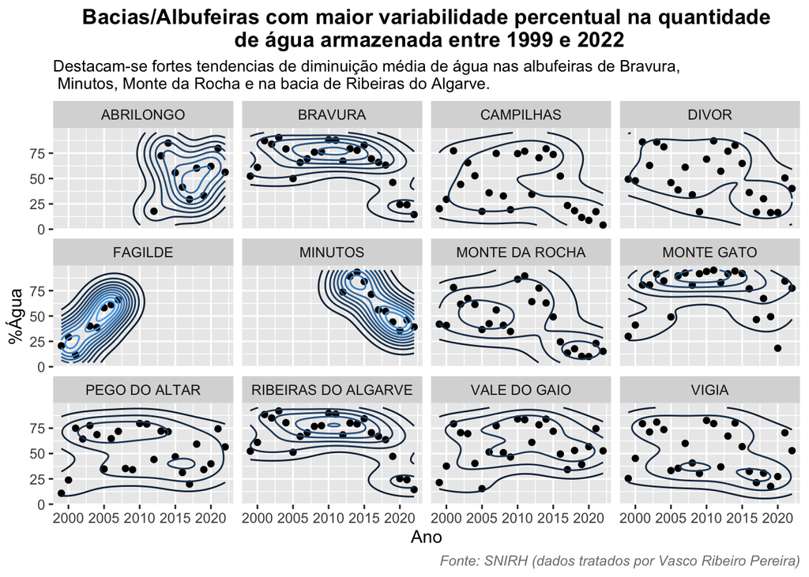

```r
print(average_plot)
```